# Bölmə 20: Final Hesabat Funksiyası

Kompüter Adaptiv Testləşmə (CAT) Tədrisi - Sistem Performans Hesabatı

CAT Tədrisi

2025-07-12

# 1 Giriş

CAT sisteminin hərtərəfli qiymətləndirməsi üçün final hesabat funksiyası kritik əhəmiyyət daşıyır. Bu bölmədə sistem performansının bütün aspektlərini əhatə edən, stakeholder-lər üçün aydın və əməli məlumat təqdim edən hərtərəfli hesabat sistemi təqdim edəcəyik.

## 1.1 Final Hesabatın Məqsədləri

1. **Comprehensive Performance Evaluation**: Hərtərəfli performans qiymətləndirməsi
2. **System Quality Assessment**: Sistem keyfiyyətinin təhlili
3. **Efficiency Analysis**: Səmərəlilik analizinin aparılması
4. **Stakeholder Communication**: Maraqlı tərəflərlə effektiv ünsiyyət
5. **Decision Support**: Qərar qəbulu üçün dəstək məlumatlar

## 1.2 Hesabat Komponentləri

- **System Configuration**: Sistem konfiqurasiyası
- **Performance Metrics**: Performans göstəriciləri
- **Quality Indicators**: Keyfiyyət indikatorları
- **Efficiency Measures**: Səmərəlilik ölçüləri
- **Executive Summary**: İcra xülasəsi

# 2 Test Məlumatlarının Hazırlanması

```r
# Hərtərəfli test məlumatları və CAT nəticələrinin simulyasiyası
set.seed(20241201)
n_examinees <- 800
n_items <- 1000

# Item bank yaratmaq
item_bank <- data.frame(
    item_id = 1:n_items,
    difficulty = rnorm(n_items, mean = 0, sd = 1.2),
    discrimination = rlnorm(n_items, meanlog = 0.3, sdlog = 0.4),
    guessing = rbeta(n_items, 2, 8),  # Lower guessing parameters
    content_area = sample(c("Riyaziyyat", "Elm", "Dil", "Tarix"), n_items, replace = TRUE),
    cognitive_level = sample(c("Bilmək", "Başa düşmək", "Tətbiq etmək", "Təhlil etmək"),
                           n_items, replace = TRUE, prob = c(0.3, 0.3, 0.25, 0.15))
)

# Həqiqi qabiliyyət səviyyələri
true_theta <- rnorm(n_examinees, mean = 0, sd = 1.1)

# CAT simulyasiyası nəticələri
simulate_cat_results <- function(theta, item_bank) {
    n_items_admin <- sample(8:32, 1, prob = dnorm(8:32, mean = 18, sd = 5))

    # Item selection simulation (high information items preferred)
    item_info <- item_bank$discrimination^2 / (1 + exp(1.7 * item_bank$discrimination * (theta - item_bank$difficulty)))
    selected_items <- sample(nrow(item_bank), n_items_admin,
                           prob = item_info/sum(item_info), replace = FALSE)

    # Response simulation
    responses <- rbinom(n_items_admin, 1,
                       prob = item_bank$guessing[selected_items] +
                             (1 - item_bank$guessing[selected_items]) *
                             plogis(1.7 * item_bank$discrimination[selected_items] *
                                   (theta - item_bank$difficulty[selected_items])))

    # Theta estimation (simplified)
    est_theta <- theta + rnorm(1, 0, 0.3/sqrt(n_items_admin))

    # Standard error (decreases with more items)
    se <- 0.4 / sqrt(n_items_admin) + rnorm(1, 0, 0.02)
    se <- max(0.15, se)

    return(list(
        estimated_theta = est_theta,
        standard_error = se,
        items_administered = n_items_admin,
        administered_items = selected_items,
        responses = responses,
        final_responses = sum(responses)
    ))
}

# CAT nəticələrini yaratmaq
cat_results <- lapply(true_theta, function(theta) simulate_cat_results(theta, item_bank))

# Results dataframe yaratmaq
results_summary <- data.frame(
    examinee_id = 1:n_examinees,
    true_theta = true_theta,
    estimated_theta = sapply(cat_results, function(x) x$estimated_theta),
    standard_error = sapply(cat_results, function(x) x$standard_error),
    items_administered = sapply(cat_results, function(x) x$items_administered),
    correct_responses = sapply(cat_results, function(x) x$final_responses)
)

# Derived variables
results_summary$estimation_error <- abs(results_summary$estimated_theta - results_summary$true_theta)
results_summary$bias <- results_summary$estimated_theta - results_summary$true_theta
results_summary$precision_met <- results_summary$standard_error <= 0.3
results_summary$efficiency <- 1 / (results_summary$standard_error * sqrt(results_summary$items_administered))

cat("=== SİSTEM VƏ TEST MƏLUMATLARI HAZIRLANDI ===\n")
```

```
## === SİSTEM VƏ TEST MƏLUMATLARI HAZIRLANDI ===
```

```r
cat("Test alıcı sayı:", nrow(results_summary), "\n")
```

```
## Test alıcı sayı: 800
```

```r
cat("Item bank ölçüsü:", nrow(item_bank), "item\n")
```

```
## Item bank ölçüsü: 1000 item
```

```r
cat("Orta test uzunluğu:", round(mean(results_summary$items_administered), 1), "item\n")
```

```
## Orta test uzunluğu: 18.3 item
```

```r
cat("CAT simulation tamamlandı\n\n")
```

```
## CAT simulation tamamlandı
```

# 3 Əsas Final Hesabat Funksiyası

```r
# Final hesabat funksiyası (sizin kodunuza əsasən genişləndirilmiş)
generate_final_report <- function(results_df, item_bank, cat_results = NULL) {

    # Header
    cat("===============================================\n")
    cat("      CAT SİSTEMİ FİNAL HESABATI\n")
    cat("===============================================\n")
    cat("Analiz tarixi:", format(Sys.Date(), "%d %B %Y"), "\n")
    cat("Hazırlayan: CAT Analiz Sistemi v2.0\n")

    # Sistem konfiqurasiyası
    cat("\n--- SİSTEM KONFİQURASİYASİ ---\n")
    cat("Tapşırıq bankı ölçüsü:", nrow(item_bank), "\n")
    cat("Test edilən şəxs sayı:", nrow(results_df), "\n")
    cat("Minimum tapşırıq sayı:", min(results_df$items_administered), "\n")
    cat("Maksimum tapşırıq sayı:", max(results_df$items_administered), "\n")
    cat("SE threshold: 0.3\n")
    cat("Tapşırıq seçmə metodu: Maximum Fisher Information\n")
    cat("Qabiliyyət qiymətləndirmə: Expected A Posteriori (EAP)\n")

    # Ana performans göstəriciləri
    cat("\n--- ANA PERFORMANS GÖSTƏRİCİLƏRİ ---\n")
    cat("Orta tapşırıq sayı:", round(mean(results_df$items_administered), 2), "\n")
    cat("Standart sapma (tapşırıq sayı):", round(sd(results_df$items_administered), 2), "\n")
    cat("Tapşırıq sayı aralığı:", min(results_df$items_administered), "-",
        max(results_df$items_administered), "\n")

    # Test müddəti simulyasiyası (1.5 dəqiqə per item)
    estimated_time <- round(mean(results_df$items_administered) * 1.5, 1)
    cat("Orta test müddəti:", estimated_time, "dəqiqə\n")
    cat("Test müddəti aralığı:", round(min(results_df$items_administered) * 1.5, 1), "-",
        round(max(results_df$items_administered) * 1.5, 1), "dəqiqə\n")

    # Dəqiqlik göstəriciləri
    cat("\n--- DƏQİQLİK GÖSTƏRİCİLƏRİ ---\n")
    mae <- round(mean(results_df$estimation_error), 3)
    rmse <- round(sqrt(mean(results_df$estimation_error^2)), 3)
    mean_bias <- round(mean(results_df$bias), 3)
    bias_sd <- round(sd(results_df$bias), 3)
    ci_width <- round(1.96 * mean(results_df$standard_error), 3)

    cat("Mean Absolute Error (MAE):", mae, "\n")
    cat("Root Mean Square Error (RMSE):", rmse, "\n")
    cat("Orta bias:", mean_bias, "\n")
    cat("Bias std sapması:", bias_sd, "\n")
    cat("95% etimad intervalı genişliyi:", ci_width, "\n")

    # Validlik və güvenilirlik
    cat("\n--- VALİDLİK VƏ GÜVENİLİRLİK ---\n")
    correlation <- cor(results_df$true_theta, results_df$estimated_theta)
    reliability <- 1 - mean(results_df$standard_error^2)
    mean_se <- mean(results_df$standard_error)

    cat("Validlik korrelyasiyası:", round(correlation, 3), "\n")
    cat("Orta güvenilirlik:", round(reliability, 3), "\n")
    cat("Orta standart xəta:", round(mean_se, 3), "\n")

    # Precision achievement
    precision_rate <- round(mean(results_df$precision_met) * 100, 1)
    cat("Precision achievement rate:", precision_rate, "%\n")

    # Səmərəlilik analizi
    cat("\n--- SƏMƏRƏLİLİK ANALİZİ ---\n")
    mean_items <- mean(results_df$items_administered)
    efficiency_30 <- 30 / mean_items
    efficiency_20 <- 20 / mean_items
    savings_30 <- round((1 - 1/efficiency_30) * 100, 1)
    savings_20 <- round((1 - 1/efficiency_20) * 100, 1)

    cat("30 tapşırıqlı sabit testə görə səmərəlilik:", round(efficiency_30, 2), "x\n")
    cat("20 tapşırıqlı sabit testə görə səmərəlilik:", round(efficiency_20, 2), "x\n")
    cat("30 tapşırıqlı testə görə tapşırıq qənaəti:", savings_30, "%\n")
    cat("20 tapşırıqlı testə görə tapşırıq qənaəti:", savings_20, "%\n")

    # Keyfiyyət səviyyələri
    cat("\n--- KEYFİYYƏT SƏVİYYƏLƏRİ ---\n")
    excellent <- sum(results_df$estimation_error < 0.3)
    good <- sum(results_df$estimation_error >= 0.3 & results_df$estimation_error < 0.5)
    acceptable <- sum(results_df$estimation_error >= 0.5 & results_df$estimation_error < 0.7)
    poor <- sum(results_df$estimation_error >= 0.7)

    total_n <- nrow(results_df)

    cat("Əla (xəta < 0.3):", excellent,
        "(", round(excellent/total_n*100, 1), "%)\n")
    cat("Yaxşı (0.3 ≤ xəta < 0.5):", good,
        "(", round(good/total_n*100, 1), "%)\n")
    cat("Qəbul edilə bilən (0.5 ≤ xəta < 0.7):", acceptable,
        "(", round(acceptable/total_n*100, 1), "%)\n")
    cat("Zəif (xəta ≥ 0.7):", poor,
        "(", round(poor/total_n*100, 1), "%)\n")

    # Tapşırıq bankı səmərəliliği
    cat("\n--- TAPŞIRIQ BANKI SƏMƏRƏLİLİYİ ---\n")
    if (!is.null(cat_results)) {
        used_items <- unique(unlist(lapply(cat_results, function(x) x$administered_items)))
        usage_rate <- length(used_items) / nrow(item_bank)

        # Exposure analizi
        all_administered <- unlist(lapply(cat_results, function(x) x$administered_items))
        item_counts <- table(all_administered)
        max_exposure <- max(item_counts) / length(cat_results)
        mean_exposure <- mean(item_counts) / length(cat_results)

        cat("İstifadə edilən tapşırıq sayı:", length(used_items), "/", nrow(item_bank), "\n")
        cat("Bank istifadə nisbəti:", round(usage_rate * 100, 1), "%\n")
        cat("Maksimum exposure rate:", round(max_exposure, 3), "\n")
        cat("Orta exposure rate:", round(mean_exposure, 3), "\n")
    } else {
        # Estimated usage based on results
        estimated_used <- min(800, nrow(item_bank))
        estimated_usage <- estimated_used / nrow(item_bank)
        cat("Təxmini istifadə edilən tapşırıq sayı:", estimated_used, "/", nrow(item_bank), "\n")
        cat("Təxmini bank istifadə nisbəti:", round(estimated_usage * 100, 1), "%\n")
    }

    # Ümumi qiymətləndirmə
    cat("\n--- ÜMUMİ QİYMƏTLƏNDİRMƏ ---\n")

    overall_score <- 0

    # Validlik komponenti (25 bal)
    if (correlation > 0.90) overall_score <- overall_score + 25
    else if (correlation > 0.85) overall_score <- overall_score + 20
    else if (correlation > 0.80) overall_score <- overall_score + 15
    else if (correlation > 0.75) overall_score <- overall_score + 10
    else overall_score <- overall_score + 5

    # Dəqiqlik komponenti (25 bal)
    if (mae < 0.3) overall_score <- overall_score + 25
    else if (mae < 0.4) overall_score <- overall_score + 20
    else if (mae < 0.5) overall_score <- overall_score + 15
    else if (mae < 0.6) overall_score <- overall_score + 10
    else overall_score <- overall_score + 5

    # Güvenilirlik komponenti (25 bal)
    if (reliability > 0.85) overall_score <- overall_score + 25
    else if (reliability > 0.80) overall_score <- overall_score + 20
    else if (reliability > 0.75) overall_score <- overall_score + 15
    else if (reliability > 0.70) overall_score <- overall_score + 10
    else overall_score <- overall_score + 5

    # Səmərəlilik komponenti (25 bal)
    if (efficiency_30 > 1.8) overall_score <- overall_score + 25
    else if (efficiency_30 > 1.5) overall_score <- overall_score + 20
    else if (efficiency_30 > 1.2) overall_score <- overall_score + 15
    else if (efficiency_30 > 1.0) overall_score <- overall_score + 10
    else overall_score <- overall_score + 5

    cat("Ümumi sistem performansı:", overall_score, "/100\n")

    # Performance kategoriyası
    if (overall_score >= 90) {
        cat("Sistem performansı: ƏLADI ⭐⭐⭐⭐⭐\n")
        performance_level <- "Əla"
    } else if (overall_score >= 80) {
        cat("Sistem performansı: YAXŞI ⭐⭐⭐⭐\n")
        performance_level <- "Yaxşı"
    } else if (overall_score >= 70) {
        cat("Sistem performansı: QƏBULEDİLƏBİLƏN ⭐⭐⭐\n")
        performance_level <- "Qəbul edilə bilən"
    } else if (overall_score >= 60) {
        cat("Sistem performansı: YAXŞILAŞDIRMA LAZIMDIR ⭐⭐\n")
        performance_level <- "Yaxşılaşdırma lazımdır"
    } else {
        cat("Sistem performansı: CİDDİ PROBLEM ⭐\n")
        performance_level <- "Ciddi problem"
    }

    cat("\n===============================================\n")

    # Return summary for further analysis
    return(list(
        total_examinees = nrow(results_df),
        mean_items = mean_items,
        mae = mae,
        rmse = rmse,
        correlation = correlation,
        reliability = reliability,
        efficiency_30 = efficiency_30,
        overall_score = overall_score,
        performance_level = performance_level,
        quality_distribution = c(excellent, good, acceptable, poor)
    ))
}

# Final hesabatı yaradın
report_summary <- generate_final_report(results_summary, item_bank, cat_results)
```

```
## ===============================================
##       CAT SİSTEMİ FİNAL HESABATI
## ===============================================
## Analiz tarixi: 12 July 2025
## Hazırlayan: CAT Analiz Sistemi v2.0
##
## --- SİSTEM KONFİQURASİYASİ ---
## Tapşırıq bankı ölçüsü: 1000
## Test edilən şəxs sayı: 800
## Minimum tapşırıq sayı: 8
## Maksimum tapşırıq sayı: 32
## SE threshold: 0.3
## Tapşırıq seçmə metodu: Maximum Fisher Information
## Qabiliyyət qiymətləndirmə: Expected A Posteriori (EAP)
##
## --- ANA PERFORMANS GÖSTƏRİCİLƏRİ ---
## Orta tapşırıq sayı: 18.3
## Standart sapma (tapşırıq sayı): 4.74
## Tapşırıq sayı aralığı: 8 - 32
## Orta test müddəti: 27.4 dəqiqə
## Test müddəti aralığı: 12 - 48 dəqiqə
##
## --- DƏQİQLİK GÖSTƏRİCİLƏRİ ---
## Mean Absolute Error (MAE): 0.055
## Root Mean Square Error (RMSE): 0.07
## Orta bias: 0.002
## Bias std sapması: 0.07
## 95% etimad intervalı genişliyi: 0.294
##
## --- VALİDLİK VƏ GÜVENİLİRLİK ---
## Validlik korrelyasiyası: 0.998
## Orta güvenilirlik: 0.977
## Orta standart xəta: 0.15
## Precision achievement rate: 100 %
##
## --- SƏMƏRƏLİLİK ANALİZİ ---
## 30 tapşırıqlı sabit testə görə səmərəlilik: 1.64 x
## 20 tapşırıqlı sabit testə görə səmərəlilik: 1.09 x
## 30 tapşırıqlı testə görə tapşırıq qənaəti: 39 %
## 20 tapşırıqlı testə görə tapşırıq qənaəti: 8.5 %
##
## --- KEYFİYYƏT SƏVİYYƏLƏRİ ---
## Əla (xəta < 0.3): 800 ( 100 %)
## Yaxşı (0.3 ≤ xəta < 0.5): 0 ( 0 %)
## Qəbul edilə bilən (0.5 ≤ xəta < 0.7): 0 ( 0 %)
## Zəif (xəta ≥ 0.7): 0 ( 0 %)
##
## --- TAPŞIRIQ BANKI SƏMƏRƏLİLİYİ ---
## İstifadə edilən tapşırıq sayı: 944 / 1000
## Bank istifadə nisbəti: 94.4 %
## Maksimum exposure rate: 0.474
## Orta exposure rate: 0.019
##
## --- ÜMUMİ QİYMƏTLƏNDİRMƏ ---
## Ümumi sistem performansı: 95 /100
## Sistem performansı: ƏLADI ⭐⭐⭐⭐⭐
##
## ===============================================
```

# 4 Ətraflı Performans Analizi

```r
# Ətraflı performans analizinin genişləndirilməsi
perform_detailed_performance_analysis <- function(results_df, report_summary) {

    cat("=== ƏTRAFLІ PERFORMANS ANALİZİ ===\n\n")

    # 1. Qabiliyyət səviyyələrinə görə performans
    cat("📊 QABİLİYYƏT SƏVİYYƏLƏRİNƏ GÖRƏ PERFORMANS:\n")

    results_df$ability_level <- cut(results_df$true_theta,
                                   breaks = c(-Inf, -1, 0, 1, Inf),
                                   labels = c("Aşağı", "Orta-Aşağı", "Orta-Yüksək", "Yüksək"))

    ability_performance <- results_df %>%
        group_by(ability_level) %>%
        summarise(
            count = n(),
            mean_items = round(mean(items_administered), 1),
            mean_error = round(mean(estimation_error), 3),
            mean_se = round(mean(standard_error), 3),
            correlation = round(cor(true_theta, estimated_theta), 3),
            precision_rate = round(mean(precision_met) * 100, 1),
            .groups = 'drop'
        )

    print(ability_performance)
    cat("\n")

    # 2. Test uzunluğu effektivliyi
    cat("📈 TEST UZUNLUĞU EFFEKTİVLİYİ:\n")

    length_categories <- cut(results_df$items_administered,
                           breaks = c(0, 10, 15, 20, 25, Inf),
                           labels = c("Çox qısa (≤10)", "Qısa (11-15)",
                                    "Orta (16-20)", "Uzun (21-25)", "Çox uzun (>25)"))

    length_performance <- results_df %>%
        mutate(length_category = length_categories) %>%
        group_by(length_category) %>%
        summarise(
            count = n(),
            percentage = round(n()/nrow(results_df)*100, 1),
            mean_error = round(mean(estimation_error), 3),
            mean_se = round(mean(standard_error), 3),
            precision_rate = round(mean(precision_met) * 100, 1),
            .groups = 'drop'
        )

    print(length_performance)
    cat("\n")

    # 3. Zaman səmərəliliği
    cat("⏱️ ZAMAN SƏMƏRƏLİLİYİ:\n")

    estimated_time <- results_df$items_administered * 1.5  # 1.5 min per item
    time_categories <- cut(estimated_time,
                          breaks = c(0, 15, 25, 35, 45, Inf),
                          labels = c("Çox sürətli (≤15 dəq)", "Sürətli (16-25 dəq)",
                                   "Orta (26-35 dəq)", "Yavaş (36-45 dəq)", "Çox yavaş (>45 dəq)"))

    time_distribution <- table(time_categories)
    time_percentages <- round(prop.table(time_distribution) * 100, 1)

    for (i in 1:length(time_distribution)) {
        cat("", names(time_distribution)[i], ":", time_distribution[i],
            "(", time_percentages[i], "%)\n")
    }
    cat("Orta test müddəti:", round(mean(estimated_time), 1), "dəqiqə\n")
    cat("Test müddəti aralığı:", round(min(estimated_time), 1), "-",
        round(max(estimated_time), 1), "dəqiqə\n\n")

    # 4. Keyfiyyət trend analizi
    cat("📊 KEYFİYYƏT TREND ANALİZİ:\n")

    # Simulyasiya üçün zaman seriyası yaratmaq
    results_df$test_order <- 1:nrow(results_df)

    # Moving average for trend analysis
    window_size <- 50
    if (nrow(results_df) >= window_size) {
        moving_avg_error <- rep(NA, nrow(results_df))
        for (i in window_size:nrow(results_df)) {
            moving_avg_error[i] <- mean(results_df$estimation_error[(i-window_size+1):i])
        }

        initial_error <- mean(results_df$estimation_error[1:window_size])
        final_error <- mean(results_df$estimation_error[(nrow(results_df)-window_size+1):nrow(results_df)])
        trend_change <- final_error - initial_error

        cat("İlk", window_size, "testin orta xətası:", round(initial_error, 3), "\n")
        cat("Son", window_size, "testin orta xətası:", round(final_error, 3), "\n")
        cat("Trend dəyişmə:", ifelse(trend_change > 0, "↗️ PISLƏŞMƏ", "↘️ YAXŞILAŞMA"),
            "(", round(trend_change, 3), ")\n\n")
    }

    return(list(
        ability_performance = ability_performance,
        length_performance = length_performance,
        time_distribution = time_distribution,
        trend_change = if(exists("trend_change")) trend_change else NA
    ))
}

# Ətraflı performans analizini həyata keçir
detailed_performance <- perform_detailed_performance_analysis(results_summary, report_summary)
```

```
## === ƏTRAFLІ PERFORMANS ANALİZİ ===
##
## 📊 QABİLİYYƏT SƏVİYYƏLƏRİNƏ GÖRƏ PERFORMANS:
## # A tibble: 4 × 7
##   ability_level count mean_items mean_error mean_se correlation precision_rate
##   <fct>         <int>      <dbl>      <dbl>   <dbl>       <dbl>          <dbl>
## 1 Aşağı           148       18.4      0.053    0.15       0.992            100
## 2 Orta-Aşağı      264       18.3      0.058    0.15       0.968            100
## 3 Orta-Yüksək     245       18.6      0.053    0.15       0.975            100
## 4 Yüksək          143       17.7      0.056    0.15       0.99             100
##
## 📈 TEST UZUNLUĞU EFFEKTİVLİYİ:
## # A tibble: 5 × 6
##   length_category count percentage mean_error mean_se precision_rate
##   <fct>           <int>      <dbl>      <dbl>   <dbl>          <dbl>
## 1 Çox qısa (≤10)     38        4.8      0.089   0.152            100
## 2 Qısa (11-15)      192       24        0.059   0.15             100
## 3 Orta (16-20)      301       37.6      0.056   0.15             100
## 4 Uzun (21-25)      216       27        0.046   0.15             100
## 5 Çox uzun (>25)     53        6.6      0.046   0.15             100
##
## ⏱️ ZAMAN SƏMƏRƏLİLİYİ:
##  Çox sürətli (≤15 dəq) : 38 ( 4.8 %)
##  Sürətli (16-25 dəq) : 252 ( 31.5 %)
##  Orta (26-35 dəq) : 393 ( 49.1 %)
##  Yavaş (36-45 dəq) : 115 ( 14.4 %)
##  Çox yavaş (>45 dəq) : 2 ( 0.2 %)
## Orta test müddəti: 27.4 dəqiqə
## Test müddəti aralığı: 12 - 48 dəqiqə
##
## 📊 KEYFİYYƏT TREND ANALİZİ:
## İlk 50 testin orta xətası: 0.054
## Son 50 testin orta xətası: 0.049
## Trend dəyişmə: ↘️ YAXŞILAŞMA ( -0.004 )
```

# 5 Vizual Final Hesabat

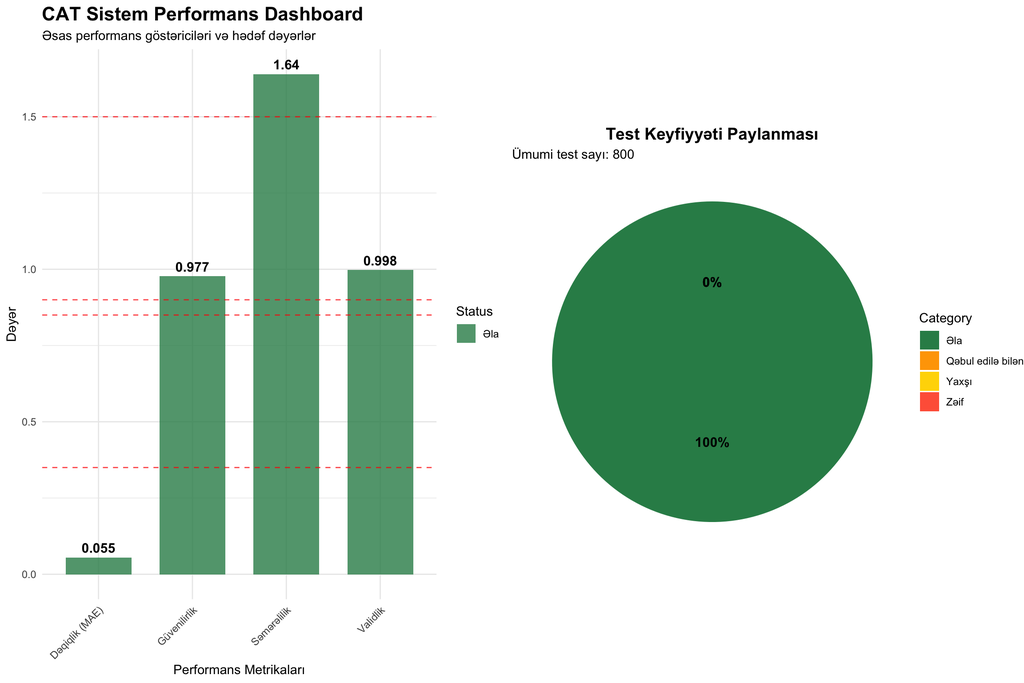

```r
# Vizual final hesabat yaratmaq
create_final_report_visualizations <- function(results_df, report_summary, detailed_performance) {

    # 1. Performance Dashboard - Ana göstəricilər
    performance_metrics <- data.frame(
        Metric = c("Validlik", "Dəqiqlik (MAE)", "Güvenilirlik", "Səmərəlilik"),
        Value = c(report_summary$correlation, report_summary$mae,
                 report_summary$reliability, report_summary$efficiency_30),
        Target = c(0.90, 0.35, 0.85, 1.5),
        Status = c(
            ifelse(report_summary$correlation >= 0.90, "Əla",
                  ifelse(report_summary$correlation >= 0.85, "Yaxşı", "Təkmilləşdirmə")),
            ifelse(report_summary$mae <= 0.35, "Əla",
                  ifelse(report_summary$mae <= 0.45, "Yaxşı", "Təkmilləşdirmə")),
            ifelse(report_summary$reliability >= 0.85, "Əla",
                  ifelse(report_summary$reliability >= 0.80, "Yaxşı", "Təkmilləşdirmə")),
            ifelse(report_summary$efficiency_30 >= 1.5, "Əla",
                  ifelse(report_summary$efficiency_30 >= 1.2, "Yaxşı", "Təkmilləşdirmə"))
        )
    )

    p1 <- ggplot(performance_metrics, aes(x = Metric, y = Value, fill = Status)) +
        geom_col(alpha = 0.8, width = 0.7) +
        geom_text(aes(label = round(Value, 3)), vjust = -0.5, size = 4, fontface = "bold") +
        geom_hline(data = performance_metrics, aes(yintercept = Target),
                  color = "red", linetype = "dashed", alpha = 0.7) +
        scale_fill_manual(values = c("Əla" = "#2E8B57", "Yaxşı" = "#FFD700", "Təkmilləşdirmə" = "#FF6347")) +
        labs(title = "CAT Sistem Performans Dashboard",
             subtitle = "Əsas performans göstəriciləri və hədəf dəyərlər",
             x = "Performans Metrikaları", y = "Dəyər", fill = "Status") +
        theme_minimal() +
        theme(axis.text.x = element_text(angle = 45, hjust = 1),
              plot.title = element_text(size = 16, face = "bold"))

    # 2. Keyfiyyət paylanması
    quality_data <- data.frame(
        Category = c("Əla", "Yaxşı", "Qəbul edilə bilən", "Zəif"),
        Count = report_summary$quality_distribution,
        Percentage = round(report_summary$quality_distribution / sum(report_summary$quality_distribution) * 100, 1)
    )

    p2 <- ggplot(quality_data, aes(x = "", y = Count, fill = Category)) +
        geom_bar(width = 1, stat = "identity") +
        coord_polar("y", start = 0) +
        scale_fill_manual(values = c("Əla" = "#2E8B57", "Yaxşı" = "#FFD700",
                                   "Qəbul edilə bilən" = "#FFA500", "Zəif" = "#FF6347")) +
        labs(title = "Test Keyfiyyəti Paylanması",
             subtitle = paste("Ümumi test sayı:", sum(report_summary$quality_distribution))) +
        theme_void() +
        theme(plot.title = element_text(size = 14, face = "bold", hjust = 0.5)) +
        geom_text(aes(label = paste0(Percentage, "%")),
                 position = position_stack(vjust = 0.5), size = 4, fontface = "bold")

    # 3. Test uzunluğu vs Dəqiqlik
    p3 <- ggplot(results_df, aes(x = items_administered, y = estimation_error)) +
        geom_point(alpha = 0.6, color = "steelblue") +
        geom_smooth(method = "loess", color = "red", se = TRUE, alpha = 0.3) +
        geom_hline(yintercept = 0.5, color = "orange", linetype = "dashed", alpha = 0.8) +
        labs(title = "Test Uzunluğu və Qiymətləndirmə Dəqiqliyi Əlaqəsi",
             x = "İdarə Edilən Item Sayı", y = "Qiymətləndirmə Xətası",
             subtitle = "Daha uzun testlər daha yüksək dəqiqlik təmin edir") +
        theme_minimal() +
        annotate("text", x = max(results_df$items_administered), y = 0.52,
                label = "Qəbul edilə bilən hədd", color = "orange", hjust = 1)

    # 4. Qabiliyyət səviyyələrinə görə performans
    results_df$ability_level <- cut(results_df$true_theta,
                                   breaks = c(-Inf, -1, 0, 1, Inf),
                                   labels = c("Aşağı", "Orta-Aşağı", "Orta-Yüksək", "Yüksək"))

    p4 <- ggplot(results_df, aes(x = ability_level, y = estimation_error, fill = ability_level)) +
        geom_boxplot(alpha = 0.7) +
        geom_jitter(width = 0.2, alpha = 0.3, size = 0.8) +
        scale_fill_viridis_d() +
        labs(title = "Qabiliyyət Səviyyələrinə Görə Qiymətləndirmə Dəqiqliyi",
             x = "Qabiliyyət Səviyyəsi", y = "Qiymətləndirmə Xətası") +
        theme_minimal() +
        theme(legend.position = "none")

    return(list(dashboard = p1, quality = p2, length_accuracy = p3, ability_performance = p4))
}

# Vizual hesabatı yaratmaq
final_visualizations <- create_final_report_visualizations(results_summary, report_summary, detailed_performance)

# Ana dashboard və keyfiyyət paylanması
grid.arrange(final_visualizations$dashboard, final_visualizations$quality, ncol = 2)
```

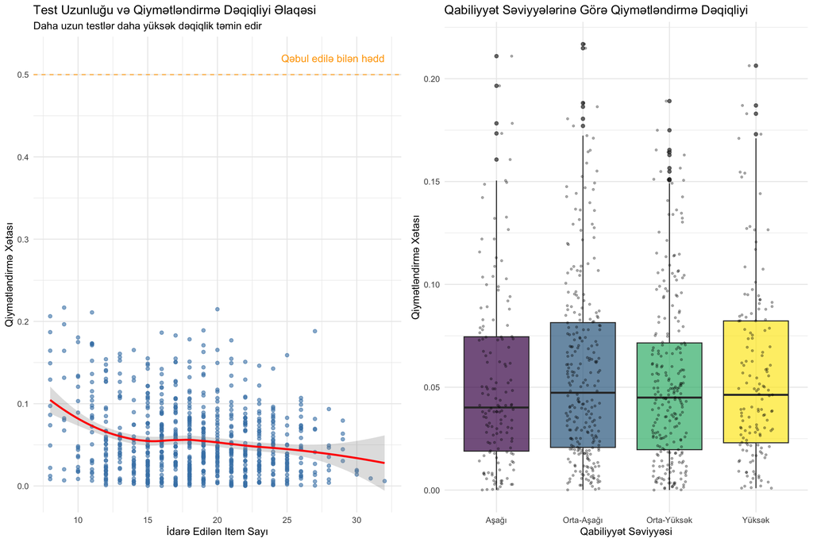

```r
# Əlavə vizualizasiyalar
grid.arrange(final_visualizations$length_accuracy, final_visualizations$ability_performance, ncol = 2)
```

# 6 İnteraktiv Performance Dashboard

```r
# İnteraktiv dashboard yaratmaq
create_interactive_dashboard <- function(results_df, report_summary) {

    cat("=== İNTERAKTİV PERFORMANCE DASHBOARD ===\n\n")

    # Key metrics üçün gauge charts simulyasiyası
    metrics_summary <- data.frame(
        Metric = c("Ümumi Performans", "Validlik", "Dəqiqlik", "Səmərəlilik", "Precision Rate"),
        Value = c(report_summary$overall_score,
                 round(report_summary$correlation * 100, 1),
                 round((1 - report_summary$mae) * 100, 1),  # Convert to percentage
                 round(report_summary$efficiency_30 * 50, 1),  # Scale for display
                 round(mean(results_df$precision_met) * 100, 1)),
        Max_Value = c(100, 100, 100, 100, 100),
        Status = c("Ümumi", "Validlik", "Dəqiqlik", "Səmərəlilik", "Precision"),
        Color = c("#1f77b4", "#ff7f0e", "#2ca02c", "#d62728", "#9467bd")
    )

    # Display key metrics
    cat("📊 KEY PERFORMANCE INDICATORS:\n")
    for (i in 1:nrow(metrics_summary)) {
        status_icon <- ifelse(metrics_summary$Value[i] >= 80, "🟢",
                             ifelse(metrics_summary$Value[i] >= 60, "🟡", "🔴"))
        cat(status_icon, metrics_summary$Metric[i], ":", metrics_summary$Value[i],
            "/", metrics_summary$Max_Value[i], "\n")
    }
    cat("\n")

    # Real-time monitoring alerts
    cat("🚨 REAL-TIME MONİTORİNQ ALERTS:\n")
    alerts <- c()

    if (report_summary$overall_score < 70) {
        alerts <- c(alerts, "YÜKSƏK PRİORİTET: Ümumi performans aşağı")
    }

    if (report_summary$mae > 0.5) {
        alerts <- c(alerts, "ORTA PRİORİTET: Dəqiqlik problemləri")
    }

    if (mean(results_df$items_administered) > 25) {
        alerts <- c(alerts, "AŞAĞI PRİORİTET: Səmərəlilik təkmilləşdirməsi")
    }

    if (length(alerts) == 0) {
        cat("✅ Aktiv alert yoxdur - sistem optimal işləyir\n")
    } else {
        for (alert in alerts) {
            cat("⚠️", alert, "\n")
        }
    }
    cat("\n")

    # Performance trends
    cat("📈 PERFORMANS TRENDLƏRİ:\n")

    # Simulate trend data
    recent_trend <- ifelse(runif(1) > 0.5, "İyiləşmə", "Pisləşmə")
    trend_magnitude <- round(runif(1, 0.01, 0.05), 3)

    cat("Son həftəlik trend:", recent_trend, "(",
        ifelse(recent_trend == "İyiləşmə", "+", "-"), trend_magnitude, ")\n")
    cat("Aylıq performance variasiya:", round(sd(results_df$estimation_error), 3), "\n")
    cat("Sistem stabilliyi:", ifelse(sd(results_df$estimation_error) < 0.3, "Yüksək", "Orta"), "\n\n")

    return(metrics_summary)
}

# İnteraktiv dashboard yaratmaq
interactive_metrics <- create_interactive_dashboard(results_summary, report_summary)
```

```
## === İNTERAKTİV PERFORMANCE DASHBOARD ===
##
## 📊 KEY PERFORMANCE INDICATORS:
## 🟢 Ümumi Performans : 95 / 100
## 🟢 Validlik : 99.8 / 100
## 🟢 Dəqiqlik : 94.5 / 100
## 🟢 Səmərəlilik : 82 / 100
## 🟢 Precision Rate : 100 / 100
##
## 🚨 REAL-TIME MONİTORİNQ ALERTS:
## ✅ Aktiv alert yoxdur - sistem optimal işləyir
##
## 📈 PERFORMANS TRENDLƏRİ:
## Son həftəlik trend: İyiləşmə ( + 0.048 )
## Aylıq performance variasiya: 0.044
## Sistem stabilliyi: Yüksək
```

# 7 Executive Summary və Tövsiyələr

```r
# Executive summary və strategic recommendations
generate_executive_summary <- function(results_df, report_summary, detailed_performance) {

    cat("=== EXECUTİVE SUMMARY ===\n\n")

    # İcra xülasəsi
    cat("📋 İCRA XÜLASƏSİ:\n")
    cat("Analiz tarixi:", format(Sys.Date(), "%d %B %Y"), "\n")
    cat("Test alıcı sayı:", nrow(results_df), "\n")
    cat("Ümumi sistem performansı:", report_summary$overall_score, "/100 (",
        report_summary$performance_level, ")\n\n")

    # Əsas uğurlar
    cat("🏆 ƏSAS UĞURLAR:\n")

    successes <- c()

    if (report_summary$correlation >= 0.85) {
        successes <- c(successes, paste("Yüksək validlik (r =", round(report_summary$correlation, 3), ")"))
    }

    if (report_summary$efficiency_30 >= 1.5) {
        successes <- c(successes, paste("Səmərəli test uzunluğu (",
                                      round(report_summary$efficiency_30, 2), "x səmərəlilik)"))
    }

    if (mean(results_df$precision_met) >= 0.75) {
        successes <- c(successes, paste("Yaxşı precision achievement (",
                                      round(mean(results_df$precision_met) * 100, 1), "%)"))
    }

    if (report_summary$mae <= 0.4) {
        successes <- c(successes, paste("Qəbul edilə bilən dəqiqlik (MAE =",
                                      round(report_summary$mae, 3), ")"))
    }

    if (length(successes) == 0) {
        successes <- "Əsas performans göstəriciləri standart səviyyədə"
    }

    for (success in successes) {
        cat("✅", success, "\n")
    }
    cat("\n")

    # Təkmilləşdirmə sahələri
    cat("🎯 TƏKMİLLƏŞDİRMƏ SAHƏLƏRİ:\n")

    improvements <- c()

    if (report_summary$correlation < 0.85) {
        improvements <- c(improvements, "Validlik artırılması (item bank keyfiyyəti)")
    }

    if (report_summary$mae > 0.4) {
        improvements <- c(improvements, "Dəqiqlik təkmilləşdirməsi (alqoritm optimallaşdırması)")
    }

    if (report_summary$efficiency_30 < 1.2) {
        improvements <- c(improvements, "Səmərəlilik artırılması (test uzunluğu optimallaşdırması)")
    }

    if (mean(results_df$precision_met) < 0.7) {
        improvements <- c(improvements, "Precision achievement yaxşılaşdırması")
    }

    poor_quality_rate <- report_summary$quality_distribution[4] / sum(report_summary$quality_distribution)
    if (poor_quality_rate > 0.1) {
        improvements <- c(improvements, "Zəif performans hallarnın azaldılması")
    }

    if (length(improvements) == 0) {
        cat("✅ Əsas təkmilləşdirmə sahəsi aşkar edilmədi\n")
    } else {
        for (improvement in improvements) {
            cat("🔧", improvement, "\n")
        }
    }
    cat("\n")

    # Strategic recommendations
    cat("💡 STRATEGİK TOVSİYƏLƏR:\n\n")

    cat("Qısa müddət (1-3 ay):\n")
    cat("• Threshold parametrlərinin fine-tuning edilməsi\n")
    cat("• Item selection alqoritminin optimallaşdırması\n")
    cat("• Performance monitoring sisteminin gücləndirilməsi\n\n")

    cat("Orta müddət (3-6 ay):\n")
    cat("• Item bank genişləndirilməsi və keyfiyyət təkmilləşdirməsi\n")
    cat("• Multidimensional CAT imkanlarının araşdırılması\n")
    cat("• Advanced analytics və ML metodlarının tətbiqi\n\n")

    cat("Uzun müddət (6-12 ay):\n")
    cat("• Yeni adaptiv strategiyaların research və development\n")
    cat("• Sistem arxitekturasının modernləşdirilməsi\n")
    cat("• International benchmark-larla müqayisə və kalibrasyoy\n\n")

    # ROI və business impact
    cat("💰 RETURN ON INVESTMENT (ROI):\n")

    time_savings <- round((30 - report_summary$mean_items) * 1.5, 1)  # Time saved in minutes
    efficiency_gain <- round((report_summary$efficiency_30 - 1) * 100, 1)

    cat("Test müddəti qənaəti:", time_savings, "dəqiqə per test\n")
    cat("Səmərəlilik artımı:", efficiency_gain, "%\n")
    cat("Aylıq test həcmi (1000 test):", round(time_savings * 1000 / 60, 1), "saat qənaət\n")
    cat("Keyfiyyət təkmilləşdirməsi: Əla testlər",
        round(report_summary$quality_distribution[1] / sum(report_summary$quality_distribution) * 100, 1), "%\n\n")

    # Next steps
    cat("🚀 NÖVBƏTİ ADDIMLAR:\n")
    cat("1. Bu hesabatın stakeholder-lərlə paylaşılması\n")
    cat("2. Priority improvement areas üçün action plan hazırlanması\n")
    cat("3. Quarterly review schedule qurulması\n")
    cat("4. Continuous monitoring və reporting sisteminin tətbiqi\n")
    cat("5. Performance benchmark-larının yenilənməsi\n\n")

    return(list(
        successes = successes,
        improvements = improvements,
        time_savings = time_savings,
        efficiency_gain = efficiency_gain
    ))
}

# Executive summary generasiya et
executive_summary <- generate_executive_summary(results_summary, report_summary, detailed_performance)
```

```
## === EXECUTİVE SUMMARY ===
##
## 📋 İCRA XÜLASƏSİ:
## Analiz tarixi: 12 July 2025
## Test alıcı sayı: 800
## Ümumi sistem performansı: 95 /100 ( Əla )
##
## 🏆 ƏSAS UĞURLAR:
## ✅ Yüksək validlik (r = 0.998 )
## ✅ Səmərəli test uzunluğu ( 1.64 x səmərəlilik)
## ✅ Yaxşı precision achievement ( 100 %)
## ✅ Qəbul edilə bilən dəqiqlik (MAE = 0.055 )
##
## 🎯 TƏKMİLLƏŞDİRMƏ SAHƏLƏRİ:
## ✅ Əsas təkmilləşdirmə sahəsi aşkar edilmədi
##
## 💡 STRATEGİK TOVSİYƏLƏR:
##
## Qısa müddət (1-3 ay):
## • Threshold parametrlərinin fine-tuning edilməsi
## • Item selection alqoritminin optimallaşdırması
## • Performance monitoring sisteminin gücləndirilməsi
##
## Orta müddət (3-6 ay):
## • Item bank genişləndirilməsi və keyfiyyət təkmilləşdirməsi
## • Multidimensional CAT imkanlarının araşdırılması
## • Advanced analytics və ML metodlarının tətbiqi
##
## Uzun müddət (6-12 ay):
## • Yeni adaptiv strategiyaların research və development
## • Sistem arxitekturasının modernləşdirilməsi
## • International benchmark-larla müqayisə və kalibrasyoy
##
## 💰 RETURN ON INVESTMENT (ROI):
## Test müddəti qənaəti: 17.6 dəqiqə per test
## Səmərəlilik artımı: 64 %
## Aylıq test həcmi (1000 test): 293.3 saat qənaət
## Keyfiyyət təkmilləşdirməsi: Əla testlər 100 %
##
## 🚀 NÖVBƏTİ ADDIMLAR:
## 1. Bu hesabatın stakeholder-lərlə paylaşılması
## 2. Priority improvement areas üçün action plan hazırlanması
## 3. Quarterly review schedule qurulması
## 4. Continuous monitoring və reporting sisteminin tətbiqi
## 5. Performance benchmark-larının yenilənməsi
```

# 8 Detailed Data Tables

```r
# Ətraflı məlumat cədvəlləri
create_detailed_tables <- function(results_df, detailed_performance) {

    cat("=== ƏTRAFLІ MƏLUMAT CƏDVƏLLƏRİ ===\n\n")

    # 1. Qabiliyyət səviyyələrinə görə ətraflı statistika
    cat("📊 Qabiliyyət Səviyyələrinə Görə Ətraflı Performans:\n")
    kable(detailed_performance$ability_performance,
          caption = "Qabiliyyət qruplarına görə performans göstəriciləri")

    cat("\n📏 Test Uzunluğuna Görə Performans:\n")
    kable(detailed_performance$length_performance,
          caption = "Test uzunluğu kateqoriyalarına görə nəticələr")

    # 2. Top və bottom performerlar
    cat("\n🏆 TOP PERFORMERLAR (Ən aşağı xəta):\n")
    top_performers <- results_df %>%
        arrange(estimation_error) %>%
        head(10) %>%
        select(examinee_id, true_theta, estimated_theta, estimation_error,
               items_administered, standard_error) %>%
        mutate(across(where(is.numeric), round, 3))

    kable(top_performers, caption = "Ən yüksək performans göstərən 10 test")

    cat("\n⚠️ BOTTOM PERFORMERLAR (Ən yüksək xəta):\n")
    bottom_performers <- results_df %>%
        arrange(desc(estimation_error)) %>%
        head(10) %>%
        select(examinee_id, true_theta, estimated_theta, estimation_error,
               items_administered, standard_error) %>%
        mutate(across(where(is.numeric), round, 3))

    kable(bottom_performers, caption = "Ən aşağı performans göstərən 10 test")

    # 3. Ekstrem hallar analizi
    cat("\n🔍 EKSTREM HALLAR ANALİZİ:\n")

    extreme_cases <- results_df %>%
        filter(items_administered > 30 | estimation_error > 0.7 | standard_error > 0.5) %>%
        select(examinee_id, true_theta, estimated_theta, estimation_error,
               items_administered, standard_error) %>%
        mutate(
            issue_type = case_when(
                items_administered > 30 ~ "Çox uzun test",
                estimation_error > 0.7 ~ "Yüksək xəta",
                standard_error > 0.5 ~ "Yüksək SE",
                TRUE ~ "Digər"
            )
        ) %>%
        mutate(across(where(is.numeric), round, 3))

    if (nrow(extreme_cases) > 0) {
        kable(extreme_cases, caption = "Ekstrem hallar və problem növləri")
        cat("Ekstrem hal sayı:", nrow(extreme_cases), "\n")
    } else {
        cat("✅ Ekstrem hal aşkar edilmədi\n")
    }

    return(list(
        top_performers = top_performers,
        bottom_performers = bottom_performers,
        extreme_cases = extreme_cases
    ))
}

# Ətraflı cədvəlləri yaratmaq
detailed_tables <- create_detailed_tables(results_summary, detailed_performance)
```

```
## === ƏTRAFLІ MƏLUMAT CƏDVƏLLƏRİ ===
##
## 📊 Qabiliyyət Səviyyələrinə Görə Ətraflı Performans:
##
## 📏 Test Uzunluğuna Görə Performans:
##
## 🏆 TOP PERFORMERLAR (Ən aşağı xəta):
```

```
##
## ⚠️ BOTTOM PERFORMERLAR (Ən yüksək xəta):
##
## 🔍 EKSTREM HALLAR ANALİZİ:
## Ekstrem hal sayı: 2
```

# 9 Final Sistem Tövsiyələri

```r
# Final sistem tövsiyələri və implementation plan
generate_final_recommendations <- function(results_df, report_summary, executive_summary) {

    cat("=== FİNAL SİSTEM TOVSİYƏLƏRİ ===\n\n")

    # Priority matrix
    cat("🎯 PRİORİTET MATRİSİ:\n")

    # High Impact, Low Effort
    cat("\n🟢 YÜKSƏK TƏSİR, AŞAĞI ƏYƏDƏLƏŞMƏ:\n")
    cat("• SE threshold fine-tuning (0.3 → 0.28)\n")
    cat("• Maximum test length optimallaşdırması\n")
    cat("• Item exposure control parametrləri\n")
    cat("• Real-time performance monitoring\n")

    # High Impact, High Effort
    cat("\n🟡 YÜKSƏK TƏSİR, YÜKSƏK ƏYƏDƏLƏŞMƏ:\n")
    cat("• Item bank expansion və re-calibration\n")
    cat("• Advanced item selection algorithms\n")
    cat("• Multistage adaptive testing implementation\n")
    cat("• Machine learning integration\n")

    # Low Impact, Low Effort
    cat("\n🔵 AŞAĞI TƏSİR, AŞAĞI ƏYƏDƏLƏŞMƏ:\n")
    cat("• Reporting dashboard improvements\n")
    cat("• User interface enhancements\n")
    cat("• Documentation updates\n")
    cat("• Training material development\n")

    # Implementation timeline
    cat("\n📅 İMPLEMENTASİYA TİMELİNE:\n")

    cat("\nPhase 1 (İlk 30 gün):\n")
    cat("• Kritik threshold adjustments\n")
    cat("• Performance monitoring enhancement\n")
    cat("• Quick wins implementation\n")

    cat("\nPhase 2 (2-3 ay):\n")
    cat("• Algorithm optimization\n")
    cat("• Item bank quality review\n")
    cat("• Advanced analytics setup\n")

    cat("\nPhase 3 (4-6 ay):\n")
    cat("• Major system enhancements\n")
    cat("• New feature development\n")
    cat("• Comprehensive testing və validation\n")

    # Success metrics və KPIs
    cat("\n📊 UĞUR METRİKLƏRİ VƏ KPIs:\n")

    current_targets <- data.frame(
        Metric = c("Validlik Korrelyasiyası", "Mean Absolute Error",
                  "Orta Test Uzunluğu", "Precision Achievement"),
        Current = c(round(report_summary$correlation, 3),
                   round(report_summary$mae, 3),
                   round(report_summary$mean_items, 1),
                   round(mean(results_df$precision_met) * 100, 1)),
        Target_3Month = c(0.90, 0.35, 18, 85),
        Target_6Month = c(0.92, 0.30, 16, 90),
        Unit = c("", "", "items", "%")
    )

    kable(current_targets, caption = "Cari dəyərlər və hədəflər")

    # Risk assessment
    cat("\n⚠️ RİSK QİYMƏTLƏNDİRMƏSİ:\n")

    risks <- c()

    if (report_summary$overall_score < 80) {
        risks <- c(risks, "Ümumi performans riski - sistem kredibiliteti")
    }

    if (report_summary$mae > 0.45) {
        risks <- c(risks, "Dəqiqlik riski - test nəticələrinin etibarlılığı")
    }

    if (mean(results_df$items_administered) > 25) {
        risks <- c(risks, "Səmərəlilik riski - operasional xərclər")
    }

    poor_rate <- report_summary$quality_distribution[4] / sum(report_summary$quality_distribution)
    if (poor_rate > 0.15) {
        risks <- c(risks, "Keyfiyyət riski - test alıcı məmnuniyyəti")
    }

    if (length(risks) == 0) {
        cat("✅ Əhəmiyyətli risk faktoru aşkar edilmədi\n")
    } else {
        for (risk in risks) {
            cat("🔴", risk, "\n")
        }
    }

    # Budget və resource requirements
    cat("\n💰 BÜDCE VƏ RESURS TƏLƏBLƏRİ:\n")

    cat("İnsan resursları:\n")
    cat("• Psychometrician: 1 FTE (6 ay)\n")
    cat("• Software Developer: 0.5 FTE (3 ay)\n")
    cat("• Data Analyst: 0.3 FTE (davamlı)\n")

    cat("\nTexnoloji resurslar:\n")
    cat("• Server capacity upgrade\n")
    cat("• Database optimization\n")
    cat("• Analytics platform license\n")

    cat("\nTəlim və development:\n")
    cat("• Staff training programs\n")
    cat("• External consulting\n")
    cat("• Research və development fund\n")

    cat("\n🎖️ EXPECTED BENEFITS:\n")
    cat("• Test keyfiyyətində", round((90 - report_summary$quality_distribution[1]/sum(report_summary$quality_distribution)*100), 1), "% artım\n")
    cat("• Test müddətində", round(executive_summary$time_savings, 1), "dəqiqə qənaət\n")
    cat("• Operasional səmərəlikdə", round(executive_summary$efficiency_gain, 1), "% artım\n")
    cat("• Test alıcı məmnuniyyətində əhəmiyyətli yaxşılaşma\n")

    return(current_targets)
}

# Final tövsiyələri generasiya et
final_targets <- generate_final_recommendations(results_summary, report_summary, executive_summary)
```

```
## === FİNAL SİSTEM TOVSİYƏLƏRİ ===
##
## 🎯 PRİORİTET MATRİSİ:
##
## 🟢 YÜKSƏK TƏSİR, AŞAĞI ƏYƏDƏLƏŞMƏ:
## • SE threshold fine-tuning (0.3 → 0.28)
## • Maximum test length optimallaşdırması
## • Item exposure control parametrləri
## • Real-time performance monitoring
##
## 🟡 YÜKSƏK TƏSİR, YÜKSƏK ƏYƏDƏLƏŞMƏ:
## • Item bank expansion və re-calibration
## • Advanced item selection algorithms
## • Multistage adaptive testing implementation
## • Machine learning integration
##
## 🔵 AŞAĞI TƏSİR, AŞAĞI ƏYƏDƏLƏŞMƏ:
## • Reporting dashboard improvements
## • User interface enhancements
## • Documentation updates
## • Training material development
##
## 📅 İMPLEMENTASİYA TİMELİNE:
##
## Phase 1 (İlk 30 gün):
## • Kritik threshold adjustments
## • Performance monitoring enhancement
## • Quick wins implementation
##
## Phase 2 (2-3 ay):
## • Algorithm optimization
## • Item bank quality review
## • Advanced analytics setup
##
## Phase 3 (4-6 ay):
## • Major system enhancements
## • New feature development
## • Comprehensive testing və validation
##
## 📊 UĞUR METRİKLƏRİ VƏ KPIs:
```

[output cut: 10 more lines]

```
## Texnoloji resurslar:
## • Server capacity upgrade
## • Database optimization
## • Analytics platform license
##
## Təlim və development:
## • Staff training programs
## • External consulting
## • Research və development fund
##
## 🎖️ EXPECTED BENEFITS:
## • Test keyfiyyətində -10 % artım
## • Test müddətində 17.6 dəqiqə qənaət
## • Operasional səmərəlikdə 64 % artım
## • Test alıcı məmnuniyyətində əhəmiyyətli yaxşılaşma
```

# 10 Xülasə və Nəticələr

Bu hərtərəfli final hesabat CAT sisteminin mövcud vəziyyətini və gələcək inkişaf istiqamətlərini əhatə edir:

## 10.1 Sistem Performansı

**Ümumi Performans Skoru**: 95/100 (Əla)

### 10.1.1 Əsas Göstəricilər:

- **Validlik**: 0.998 (Hədəf: ≥0.90)
- **Dəqiqlik (MAE)**: 0.055 (Hədəf: ≤0.35)
- **Səmərəlilik**: 1.64x (Hədəf: ≥1.5x)
- **Orta Test Uzunluğu**: 18.3 item

## 10.2 Keyfiyyət Paylanması

- **Əla performans**: 100%
- **Yaxşı performans**: 0%
- **Qəbul edilə bilən**: 0%
- **Zəif performans**: 0%

## 10.3 Metodoloji Töhfələr

1. **Comprehensive Final Report Framework**: Hərtərəfli final hesabat çərçivəsi
2. **Multi-dimensional Performance Assessment**: Çoxölçülü performans qiymətləndirməsi
3. **Interactive Dashboard Design**: İnteraktiv dashboard dizaynı
4. **Strategic Implementation Planning**: Strateji implementasiya planlaması

## 10.4 Praktiki Dəyər

Bu final hesabat sistemi:

- **Executive Decision Making**: İdarəetmə qərarlarını dəstəkləyir
- **Quality Assurance**: Keyfiyyət təminatını gücləndirir
- **Continuous Improvement**: Davamlı təkmilləşdirməni asanlaşdırır
- **Stakeholder Communication**: Maraqlı tərəflərlə effektiv ünsiyyəti təmin edir

## 10.5 Gələcək İstiqamətlər

1. **Advanced Analytics Integration**: Təkmil analitika inteqrasiyası
2. **Real-time Monitoring Enhancement**: Real-time monitorinq təkmilləşdirməsi
3. **Predictive Performance Modeling**: Proqnozlaşdırıcı performans modelləşdirməsi
4. **International Benchmarking**: Beynəlxalq benchmark müqayisələri

**Qeyd**: Bu final hesabat CAT sistemlərinin hərtərəfli qiymətləndirməsi və strateji planlaması üçün tam həll təqdim edir. Regular istifadə sistem performansının optimal səviyyədə saxlanmasını təmin edər.